# Green Coffee ESG Intelligence

Comparative Analysis of Four Coffee Origins Using Open Data

Author

Juan Paulo Pinto Sandoval

Published

February 08, 2026

# 1 Executive Summary

This report provides a **data-driven comparative analysis** of four major coffee-producing origins (Brazil, Colombia, Peru, and Honduras) using open-source indicators spanning **1961–2024**.

**Key objectives:**

- Benchmark production capacity and trends
- Assess social vulnerability through agricultural employment patterns
- Evaluate macro-economic resilience via investment levels
- Generate a transparent ESG-style composite score

## 1.1 Key Findings

**Production Leadership:** Brazil dominates global green coffee production with 3,387,724 tonnes in 2024 (69% of analyzed origins).

**Growth Trajectory:** Brazil shows the strongest recent growth momentum with a 12.5% increase over the past 5 years.

**ESG Performance:** Brazil ranks highest in the composite ESG score (0.743), balancing production capacity with lower social vulnerability.

# 2 Business Context

## 2.1 Why Coffee Matters

The global coffee industry represents a **$200+ billion market** with profound socio-economic implications for producing regions. Coffee is a critical export commodity for Latin American economies, directly employing millions of smallholder farmers.

**ESG considerations in coffee sourcing:**

- **Environmental:** Deforestation, water usage, biodiversity
- **Social:** Labor conditions, rural poverty, gender equity
- **Governance:** Transparency, certifications, supply chain traceability

This analysis focuses on **macro-level indicators** as transparent proxies for ESG performance, enabling comparative benchmarking without relying on proprietary certification data.

# 3 Data Foundations

## 3.1 Methodology

**Data sources:**

1. **Production data:** FAOSTAT (FAO Statistical Database)
   - Indicator: Coffee, green (tonnes)
   - Time series: 1961–2024
2. **Social indicators:** World Bank Open Data
   - Employment in agriculture (% of total employment)
   - Rural population growth (annual %)
3. **Economic indicator:** World Bank Open Data
   - Gross capital formation (% of GDP)

## 3.2 Geographic Scope

Table 1: Dataset coverage by origin

| country | First Year | Last Year | Years Available | Data Points |
| --- | --- | --- | --- | --- |
| Brazil | 1,961 | 2,024 | 64 | 64 |
| Colombia | 1,961 | 2,024 | 64 | 64 |
| Honduras | 1,961 | 2,024 | 64 | 64 |
| Peru | 1,961 | 2,024 | 64 | 64 |

# 4 Production Analysis

## 4.1 Historical Production Trends

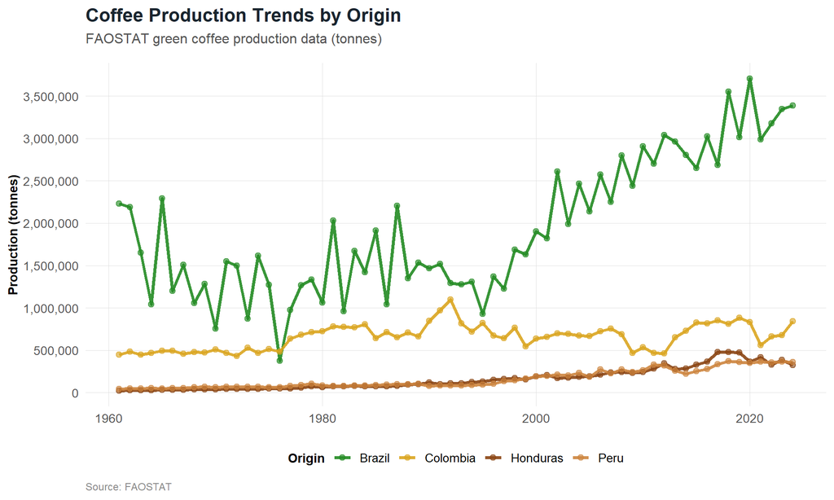

## 4.2 Market Share Analysis

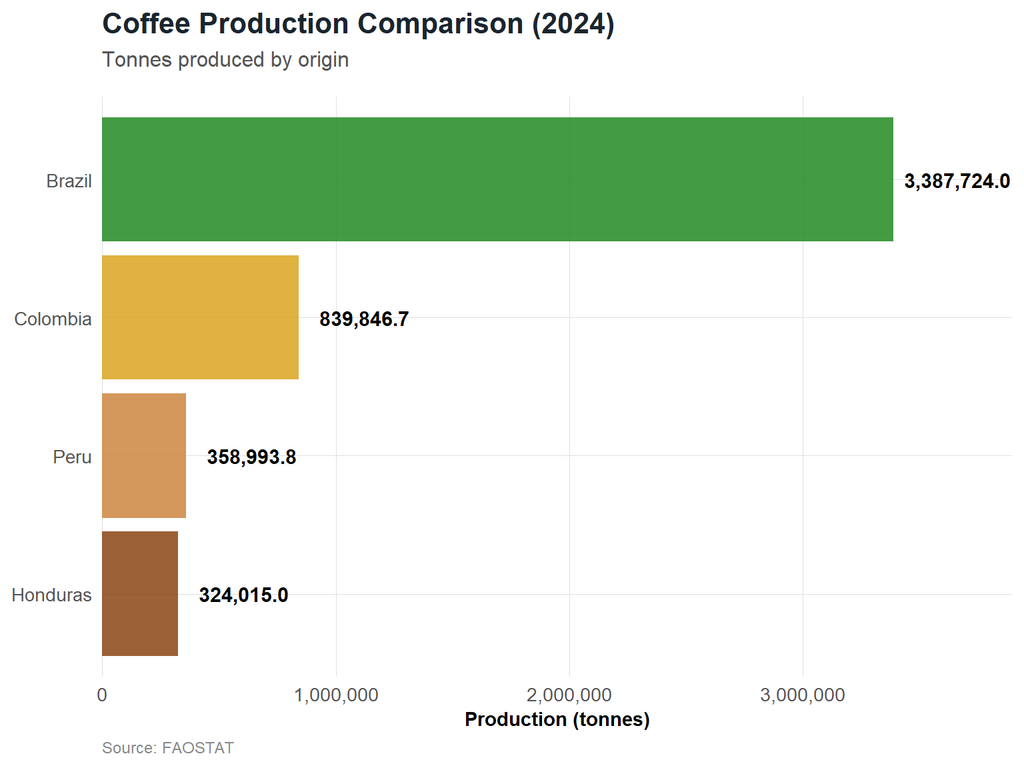

Figure 2: Production market share (latest year)

# 5 Social Indicators

## 5.1 Agricultural Employment Dependency

**Interpretation:** Higher agricultural employment percentages indicate greater economic dependence on farming and potentially higher social vulnerability to commodity price shocks.

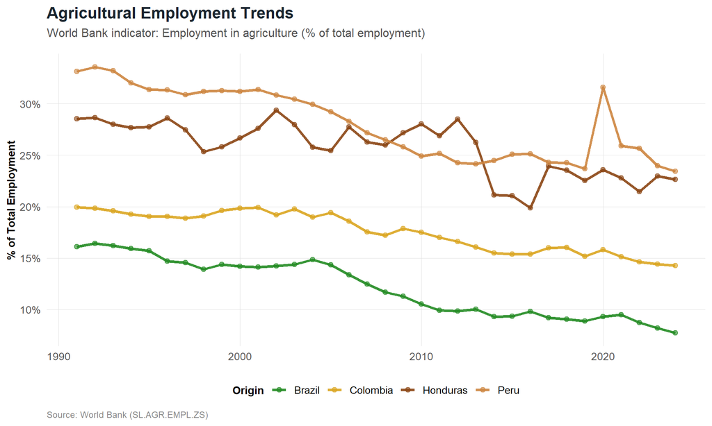

Figure 3: Employment in agriculture (% of total employment)

## 5.2 Rural Population Dynamics

**Interpretation:** Rural population growth patterns reflect demographic pressure on agricultural land and infrastructure.

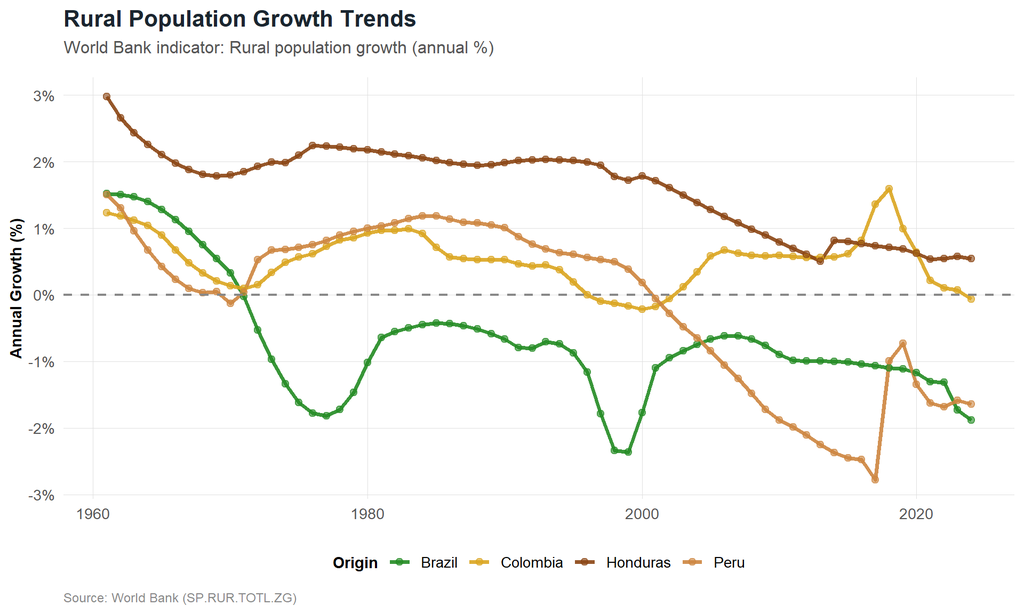

Figure 4: Rural population growth (annual %)

# 6 Economic Performance

## 6.1 Investment Capacity

**Interpretation:** Gross capital formation as % of GDP serves as a proxy for macro-economic capacity to invest in productivity improvements, infrastructure, and resilience.

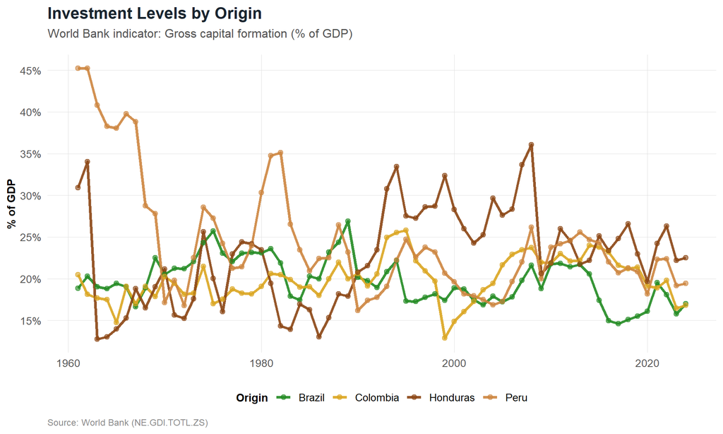

Figure 5: Gross capital formation (% of GDP)

# 7 ESG Composite Scoring

## 7.1 Methodology

The **ESG composite score** is calculated using normalized 5-year averages of four indicators:

[output not shown]

**Normalization:** All indicators are scaled to [0, 1] using min-max normalization across the four origins.

## 7.2 ESG Rankings

Table 2: ESG composite score by origin

| Country | Avg Production | Avg Employment (%) | Avg Rural Growth (%) | Avg Investment (%) | ESG Score |
| --- | --- | --- | --- | --- | --- |
| Brazil | 3,321,375 | 8.7 | -1.48 | 17.3 | 0.743 |
| Honduras | 364,126 | 22.7 | 0.57 | 23.0 | 0.300 |
| Peru | 360,097 | 26.1 | -1.58 | 20.3 | 0.282 |
| Colombia | 715,892 | 14.8 | 0.19 | 18.2 | 0.270 |

## 7.3 Visual Comparison

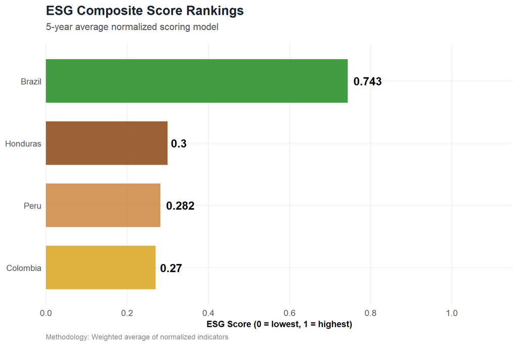

Figure 6: ESG composite score ranking (higher = stronger ESG performance)

# 8 Strategic Recommendations

## 8.1 By Origin

### 8.1.1 Brazil (ESG Score: 0.743)

**Strengths:** Highest ESG performance; balanced production capacity with lower social vulnerability.

**Opportunities:** Leverage ESG leadership for premium market positioning and sustainable sourcing partnerships.

### 8.1.2 Honduras (ESG Score: 0.3)

**Performance:** Mid-tier ESG performance with room for improvement.

**Opportunities:** Target specific indicator improvements (employment, investment, or rural growth).

### 8.1.3 Peru (ESG Score: 0.282)

**Performance:** Mid-tier ESG performance with room for improvement.

**Opportunities:** Target specific indicator improvements (employment, investment, or rural growth).

### 8.1.4 Colombia (ESG Score: 0.27)

**Opportunities:** Focus on economic diversification and productivity improvements to reduce vulnerability.

## 8.2 General Insights

1. **Production vs. Vulnerability Trade-off:** Larger producers tend to show lower agricultural employment percentages, suggesting economic diversification benefits.
2. **Investment Matters:** Origins with higher investment-to-GDP ratios demonstrate greater capacity for infrastructure and productivity improvements.
3. **Data Transparency:** This framework can be extended with environmental (deforestation, water stress) and governance (rule of law, corruption) indicators for a more comprehensive ESG assessment.

# 9 Limitations & Next Steps

## 9.1 Current Limitations

- **Macro-level indicators** do not capture farm-level realities or certification status
- **Missing environmental data** (forest loss, emissions, biodiversity)
- **No governance metrics** (corruption, rule of law, labor regulations)
- **Temporal lag** in World Bank data availability

## 9.2 Recommended Enhancements

1. **Add environmental layer:**
   - Forest cover change (Global Forest Watch)
   - Water stress indicators (WRI Aqueduct)
   - Carbon emissions intensity
2. **Incorporate governance:**
   - Corruption Perception Index (Transparency International)
   - Rule of Law Index (World Justice Project)
   - Labor rights scores (ITUC Global Rights Index)
3. **Farm-level validation:**
   - Cross-reference with certification data (Fairtrade, Rainforest Alliance)
   - Add qualitative case studies from producer cooperatives

# 10 Appendix

## 10.1 Technical Notes

- **Data processing:** All datasets cleaned using R (tidyverse ecosystem)
- **Reproducibility:** Full pipeline available in `scripts/01_pipeline_green_coffee_esg.R`
- **Normalization:** Min-max scaling applied independently to each indicator
- **Missing data:** Handled via `na.rm = TRUE` in aggregations

## 10.2 Data Access

All source data is publicly available:

- FAOSTAT: https://www.fao.org/faostat/
- World Bank Open Data: https://data.worldbank.org/

**Report generated:** 2026-02-08 22:02:19.274661

**Author:** Juan Paulo Pinto Sandoval  
**Project:** Green Coffee ESG Intelligence